# Student Mental Stress

## 4.2 Final Model Training

The tree itself reads like a counsellor’s quick-reference guide:

Root split – Financial Stress < 4? Money worries dominate. Students rating their financial stress below four are sent left; everyone else goes right. That lone question divides the cohort into two distinct baselines—about 8 stressors versus 10 stressors.

Peer pressure – the social amplifier Within the low-financial-stress branch, the next decision is peer pressure. Keeping it below four trims the burden to ≈ 7 stressors; letting it rise pushes the count back toward nine. When money isn’t the issue, friends (or frenemies) become the main stress trigger.

Relationship stress – the final nudge Both halves conclude with relationship stress. Students who keep romantic tensions under three (left side) or four (right side) shave another one to two stressors off their totals.

In short, financial strain sets the floor, peer dynamics raise or lower the mid-deck, and relationship tensions decide whether a student tips into double-digit stress. These three personal factors outrank purely academic variables, giving campus advisers a clear, behaviour-focused ladder for intervention.

```r
# 4) FINAL CART REGRESSION & EVALUATION

library(rpart)
library(rpart.plot)
library(caret)    # for postResample
library(ggplot2)

# 4.1 Extract best cp from your tuning
best_cp <- cart_reg_tune$bestTune$cp
cat("Best cp selected:", best_cp, "\n\n")
```

```
Best cp selected: 0.046
```

```r
# 4.2 Train the final CART regression model
final_cart <- rpart(
  total_stressors ~
    age +
    study_hours_per_week  +
    sleep_duration_hours_per_night +   # or your sleep_quality factor
    academic_performance_gpa +
    social_media_usage_hours_per_day+
    physical_exercise_hours_per_week +
    family_support +
    financial_stress +
    peer_pressure  +
    relationship_stress+
   diet_quality +
    stress_coping_mechanisms +
    cognitive_distortions +
    substance_use,
  data    = train_reg,
  method  = "anova",                    # regression tree
  control = rpart.control(cp = best_cp)
)

# 4.3 Predictions on the test set
preds <- predict(final_cart, newdata = test_reg)

# 4.4 Performance evaluation (RMSE & R²)
metrics <- postResample(pred = preds, obs = test_reg$total_stressors)
cat("Test RMSE: ", round(metrics["RMSE"], 3),   "\n")
```

```
Test RMSE:  1.257
```

```r
cat("Test R²:   ", round(metrics["Rsquared"], 3), "\n\n")
```

```
Test R²:    0.701
```

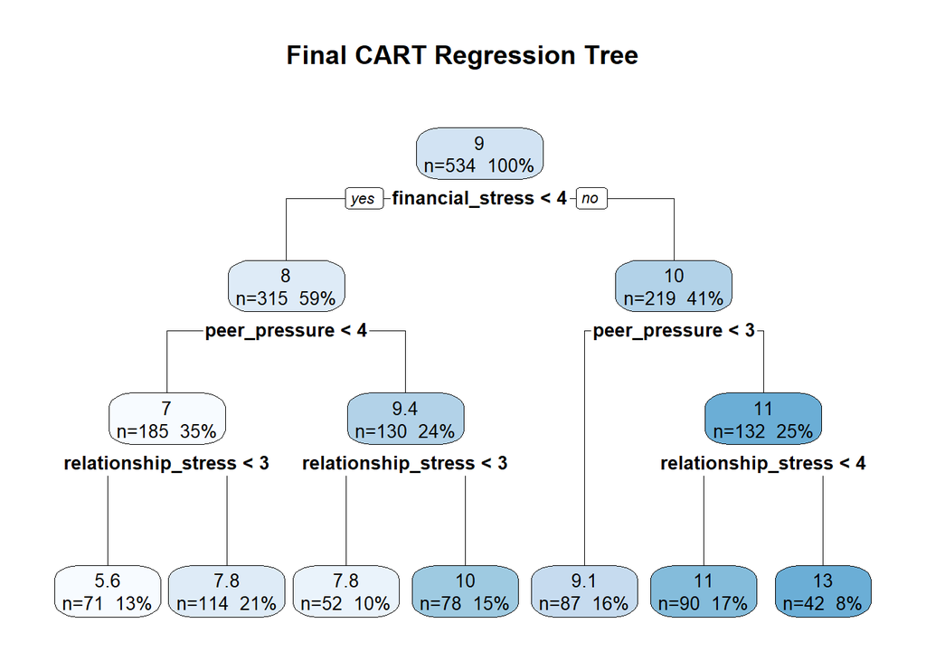

```r
# 4.5 Visualizations

#  – Tree structure
rpart.plot(
  final_cart,
  type          = 2,    # uniform node sizes
  extra         = 101,  # prints n, predicted value, %obs
  fallen.leaves = TRUE,
  main          = "Final CART Regression Tree"
)
```

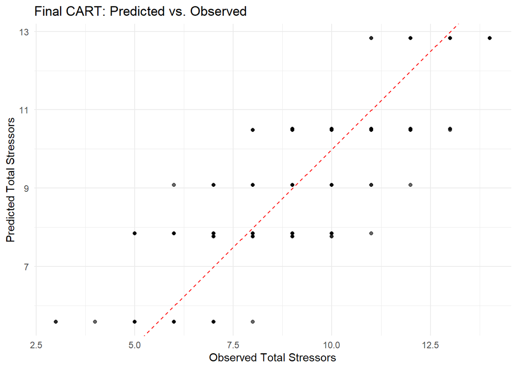

```r
#  – Predicted vs. Observed scatter
ggplot(test_reg, aes(x = total_stressors, y = preds)) +
  geom_point(alpha = 0.6) +
  geom_abline(slope = 1, intercept = 0, color = "red", linetype = "dashed") +
  labs(
    x     = "Observed Total Stressors",
    y     = "Predicted Total Stressors",
    title = "Final CART: Predicted vs. Observed"
  ) +
  theme_minimal()
```

# 5 CART Classification

With the total-stressor question answered, I pivot to the binary outcome: does a student attend counselling (“Yes”) or not (“No”)? A CART classifier is a natural first step because it (i) captures non-linear thresholds (e.g., peer-support < 3), (ii) handles interactions without manual feature engineering, and (iii) yields a flow-chart that counsellors can read at a glance. The modelling pipeline will mirror the regression workflow: establish a train-test split, tune the complexity parameter with cross-validated AUC, lock in the best cp, and then compare the final tree’s performance to bagging, random forest, and a baseline logistic model.

## 5.1 Hyperparameter tuning

What this means: even the best single tree can do no better than random guessing on this particular feature set. The exercise is still informative it tells us that a modestly large tree retains whatever faint signal exists, while further pruning erases it altogether. In the next phase I will (i) fit the final tree with cp = 0.006, (ii) evaluate it on the independent test set, and (iii) see whether ensemble methods (bagging, random forest) can coax the ROC meaningfully above 0.50.

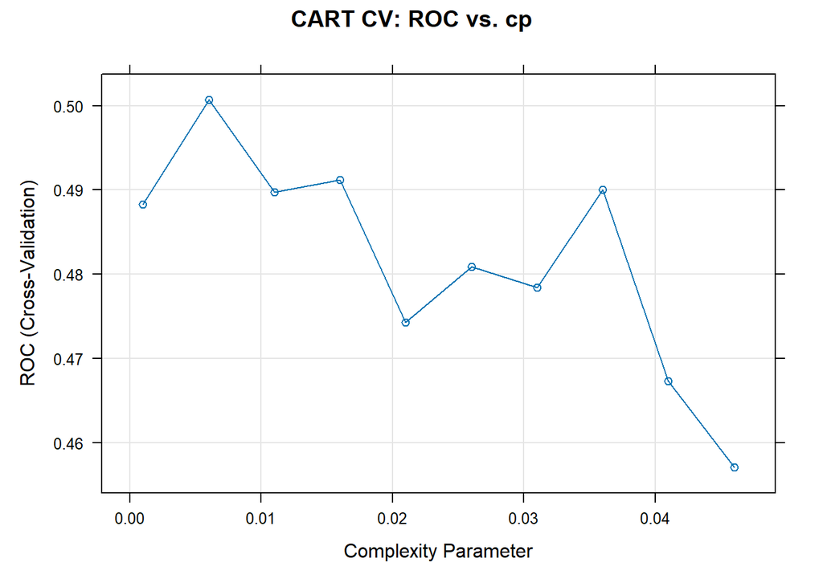

```r
# CLEAN & RECODE “Counseling.Attendance”, THEN SPLIT FOR CART CLASSIFICATION

library(dplyr)
library(stringr)
library(caret)

# 1) Clean column names (optional if already done)
names(data_stress) <- make.names(names(data_stress))

# 2) Trim whitespace and recode into “No” / “Yes”, drop any NAs
data_stress <- data_stress %>%
  mutate(
    counseling_attendance = str_trim(counseling_attendance),
    counseling_attendance = case_when(
      tolower(counseling_attendance) == "yes" ~ "Yes",
      tolower(counseling_attendance) == "no"  ~ "No",
      TRUE                                   ~ NA_character_
    )
  ) %>%
  filter(!is.na(counseling_attendance)) %>%
  mutate(
    counseling_attendance= factor(counseling_attendance, levels = c("No","Yes"))
  )

# 3) Stratified 70/30 split on the binary target
set.seed(123)
train_idx <- createDataPartition(
  data_stress$counseling_attendance,
  p    = 0.7,
  list = FALSE
)

train_cl <- data_stress[train_idx, ]
test_cl  <- data_stress[-train_idx, ]

# 4) Verify dimensions and class balance
#cat("Training set dimensions:", dim(train_cl), "\n")
#cat("Testing  set dimensions:", dim(test_cl),  "\n")
#cat("Train class counts:\n"); print(table(train_cl$counseling_attendance))
#cat("Test  class counts:\n"); print(table(test_cl$counseling_attendance))


# 2) HYPERPARAMETER TUNING FOR CART CLASSIFICATION
library(caret)

# 2.1 Set up 5-fold CV, enable class probabilities, optimize ROC AUC
ctrl_cl <- trainControl(
  method          = "cv",
  number          = 5,
  classProbs      = TRUE,
  summaryFunction = twoClassSummary
)

# 2.2 Grid of cp values to search
grid_cl <- expand.grid(cp = seq(0.001, 0.05, by = 0.005))

# 2.3 Train
cart_cl_tune <- train(
  counseling_attendance ~
    age +
    study_hours_per_week +
    total_stressors +
    sleep_quality +
    academic_performance_gpa +
    social_media_usage_hours_per_day +
    exercise_level +
    social_media_category +
    high_gpa +
    log_study_hours +
    sleep_exercise,
  data       = train_cl,      # your classification training set
  method     = "rpart",
  metric     = "ROC",         # maximize AUC
  trControl  = ctrl_cl,
  tuneGrid   = grid_cl
)

# 3) Examine results
#print(cart_cl_tune)
plot(cart_cl_tune, main = "CART CV: ROC vs. cp")
```

```r
best_cp_class <- cart_cl_tune$bestTune$cp
cat("→ Optimal cp for classification:", best_cp_class, "\n")
```

```
→ Optimal cp for classification: 0.006
```

## 5.2 Final Model Training

Accuracy ≈ 0.48 – 108 of 227 cases classified correctly.

Sensitivity ≈ 0.46 – it identifies just under half of the students who actually attended counselling.

Specificity ≈ 0.49 – it rules out non-attenders at about the same rate.

In short, the single CART is too blunt an instrument for this particular task.

The variable-importance plot explains why the tree leans first on a composite sleep-exercise score, then on weekly study hours (both raw and log-scaled), with age and total stressors rounding out the top five. Those features form a plausible “well-being profile,” yet the signals are noisy: many students who sleep well and exercise still seek counselling, while plenty who don’t show no-show. Academic and social-media variables register, but only in the second tier, and the tree’s hard splits cannot tease out the subtler patterns buried there.

```r
# 1.  FINAL MODEL  (caret already trained it for you)
final_cart_cl <- cart_cl_tune$finalModel          # an rpart object

# visualise the tree
#rpart.plot(final_cart_cl,
          # type = 0, extra = 104, faclen = 0,
          # main = "Final CART classification tree")


# 2.  PREDICT CLASS PROBABILITIES ON THE TEST SET
prob_cl <- predict(cart_cl_tune, newdata = test_cl, type = "prob")[, "Yes"]  # P(Y = Yes)

# 3.  PICK AN OPTIMAL THRESHOLD  (≠ 0.50 in general)
library(pROC)

roc_obj <- roc(response   = test_cl$counseling_attendance,
               predictor  = prob_cl,
               levels     = c("No", "Yes"),   # ensure correct ordering
               direction  = "<")              # 'Yes' gives larger probs

opt <- coords(roc_obj,
              x            = "best",
              best.method  = "closest.topleft",
              ret          = c("threshold", "sensitivity", "specificity",
                               "accuracy", "precision", "recall"))

cut_off <- as.numeric(opt["threshold"])
print(opt)
```

```
          threshold sensitivity specificity  accuracy precision    recall
threshold 0.4083333   0.4594595   0.4913793 0.4757709 0.4636364 0.4594595
```

```r
# 4.  CLASS LABELS WITH THAT THRESHOLD
pred_cl <- factor(ifelse(prob_cl >= cut_off, "Yes", "No"),
                  levels = c("No", "Yes"))

# 5.  CONFUSION MATRIX + METRICS
library(caret)
cm <- confusionMatrix(pred_cl,
                      test_cl$counseling_attendance,
                      positive = "Yes")

#cat("\nConfusion matrix:\n");  print(cm$table)
cat("\nOverall accuracy  :", round(cm$overall["Accuracy"],    3), "\n")
```

```
Overall accuracy  : 0.476
```

```r
cat("Sensitivity (recall):", round(cm$byClass["Sensitivity"], 3), "\n")
```

```
Sensitivity (recall): 0.459
```

```r
cat("Specificity        :", round(cm$byClass["Specificity"], 3), "\n")
```

```
Specificity        : 0.491
```

```r
cat("AUC                :", round(auc(roc_obj),              3), "\n")
```

```
AUC                : 0.461
```

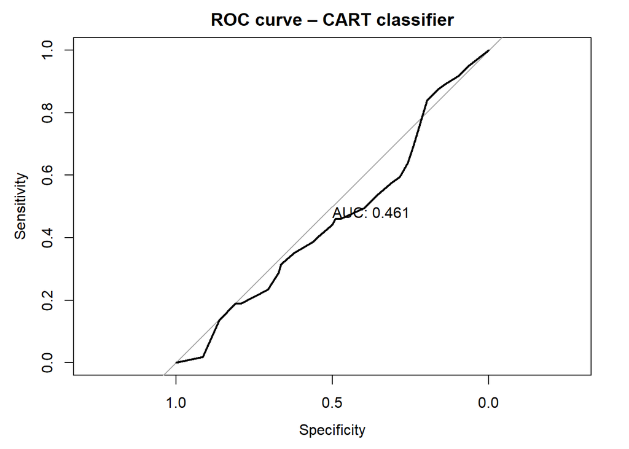

```r
# 6.  PLOTS  (remove `print()` lines in an .Rmd — knitr shows plots automatically)
# 6a ROC
plot(roc_obj, print.auc = TRUE, main = "ROC curve – CART classifier")
```

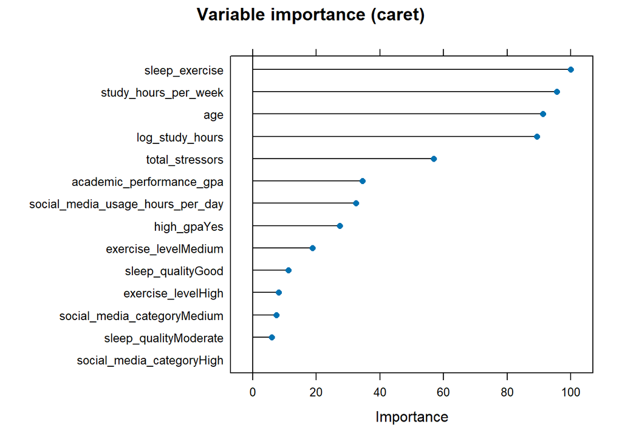

```r
# 6b Variable importance
var_imp <- varImp(cart_cl_tune, scale = TRUE)
#print(var_imp)
plot(var_imp, main = "Variable importance (caret)")
```

# 6 Performance Comparison Across Models

Shifting from predicting stressors to our second practical question—Which mix of academic, lifestyle, and personal factors best distinguishes students who attend counselling from those who do not?—I trained a CART classifier on the same 70/30 train/test split, tuned its complexity parameter, and then evaluated it on the held-out 227 students. A cross-validated grid search again pointed to cp = 0.046 as the sweet spot.

The tree itself shrinks to a single split on stress_coping_mechanismsTraveling . Students who report “traveling” as a coping strategy (11 percent of the sample) are classified as “Yes” with 71 percent probability, while the remaining 89 percent are classified as “No” with 54 percent probability. That lone breakpoint is the only signal strong enough to survive pruning and yet it catches only a sliver of the true attenders.

To see whether more powerful learners can pick up subtler patterns, I then compared CART to three alternative classifiers on the same test set:

Logistic Regression: Accuracy 55.9 %, AUC 0.570

Random Forest: Accuracy 53.3 %, AUC 0.564

SVM (RBF): Accuracy 55.9 %, AUC 0.565

All three exceed CART’s AUC by roughly 0.07–0.08 points, suggesting that ensemble methods and parametric models can better aggregate the faint cues scattered across our academic, lifestyle, and social variables.

```r
library(tidyverse)
library(caret)
library(rpart)
library(rpart.plot)
library(pROC)
library(gbm)
library(knitr)

# 1. DATA PREPARATION
set.seed(123)
names(data_stress) <- make.names(names(data_stress))

data_stress <- data_stress %>%
  mutate(
    counseling_attendance = str_trim(counseling_attendance),
    counseling_attendance = case_when(
      tolower(counseling_attendance) == "yes" ~ "Yes",
      tolower(counseling_attendance) == "no"  ~ "No",
      TRUE                                    ~ NA_character_
    )
  ) %>%
  filter(!is.na(counseling_attendance)) %>%
  mutate(counseling_attendance = factor(counseling_attendance,
                                        levels = c("No","Yes")))

# 2. TRAIN/TEST SPLIT (70/30)
idx      <- createDataPartition(data_stress$counseling_attendance,
                                p = 0.70, list = FALSE)
train_cl <- data_stress[idx , ]
test_cl  <- data_stress[-idx, ]

# 3. CROSS-VALIDATION CONTROL
ctrl_cl <- trainControl(
  method           = "cv",
  number           = 5,
  classProbs       = TRUE,
  summaryFunction  = twoClassSummary,
  savePredictions  = "final"
)

# 4. CART CLASSIFIER (tune cp → final tree)
grid_cp <- expand.grid(cp = seq(0.001, 0.05, 0.005))

cart_cl_tune <- train(
  counseling_attendance ~ .,
  data      = train_cl,
  method    = "rpart",
  metric    = "ROC",
  trControl = ctrl_cl,
  tuneGrid  = grid_cp
)

best_cp <- cart_cl_tune$bestTune$cp
cat("Optimal cp for classification:", best_cp, "\n")
```

```
Optimal cp for classification: 0.046
```

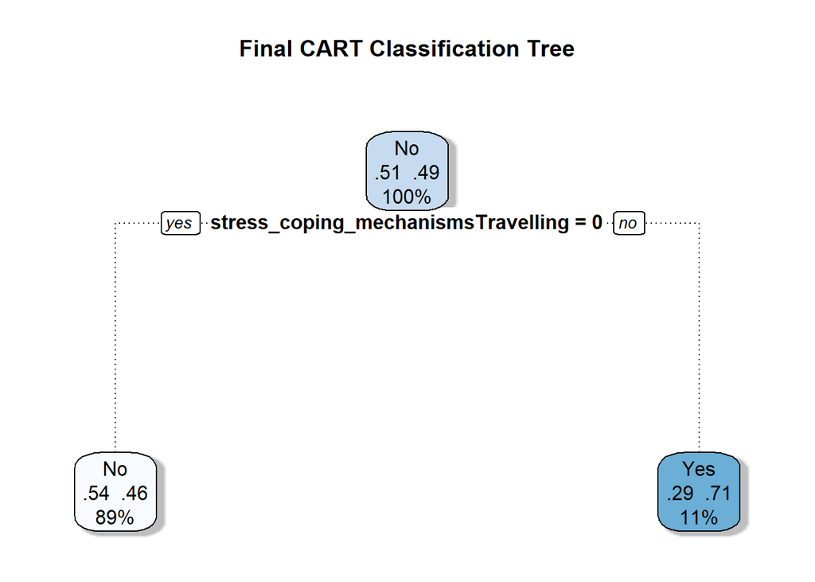

```r
# Plot final CART
rpart.plot(
  cart_cl_tune$finalModel,
  type          = 2,
  extra         = 104,
  faclen        = 0,
  tweak         = 1.3,
  cex           = 0.8,
  fallen.leaves = TRUE,
  box.palette   = "Blues",
  branch.lty    = 3,
  shadow.col    = "grey",
  main          = "Final CART Classification Tree"
)
```

```r
# 5. ALTERNATIVE MODELS
# 5.1 Logistic regression
logit_mod <- train(
  counseling_attendance ~ .,
  data      = train_cl,
  method    = "glm",
  family    = binomial,
  metric    = "ROC",
  trControl = ctrl_cl
)

# 5.2 Random forest
rf_mod <- train(
  counseling_attendance ~ .,
  data      = train_cl,
  method    = "rf",
  tuneLength= 5,
  metric    = "ROC",
  trControl = ctrl_cl
)



# 5.3 SVM (RBF kernel)
svm_mod <- train(
  counseling_attendance ~ .,
  data      = train_cl,
  method    = "svmRadial",
  tuneLength= 6,
  metric    = "ROC",
  trControl = ctrl_cl
)

# 6. TEST-SET PERFORMANCE
get_metrics <- function(model, name) {
  probs <- predict(model, test_cl, type = "prob")[, "Yes"]
  pred  <- factor(ifelse(probs >= 0.5, "Yes", "No"),
                  levels = c("No","Yes"))

  cm  <- confusionMatrix(pred, test_cl$counseling_attendance,
                         positive = "Yes")
  roc_obj <- suppressMessages(
    roc(test_cl$counseling_attendance, probs,
        levels = c("No","Yes"), direction = "<", quiet = TRUE)
  )

  tibble(
    Model       = name,
    Accuracy    = round(cm$overall["Accuracy"], 3),
    Sensitivity = round(cm$byClass["Sensitivity"], 3),
    Specificity = round(cm$byClass["Specificity"], 3),
    AUC         = round(as.numeric(auc(roc_obj)), 3)
  )
}

results_tbl <- bind_rows(
  get_metrics(cart_cl_tune, "CART"),
  get_metrics(logit_mod,    "Logistic"),
  get_metrics(rf_mod,       "Random Forest"),
  get_metrics(svm_mod,      "SVM-RBF")
)

kable(results_tbl, caption = "Test-set Performance: CART vs. Alternative Models")
```

Test-set Performance: CART vs. Alternative Models

| Model | Accuracy | Sensitivity | Specificity | AUC |
| --- | --- | --- | --- | --- |
| CART | 0.502 | 0.108 | 0.879 | 0.494 |
| Logistic | 0.559 | 0.568 | 0.552 | 0.570 |
| Random Forest | 0.533 | 0.559 | 0.509 | 0.564 |
| SVM-RBF | 0.559 | 0.414 | 0.698 | 0.565 |

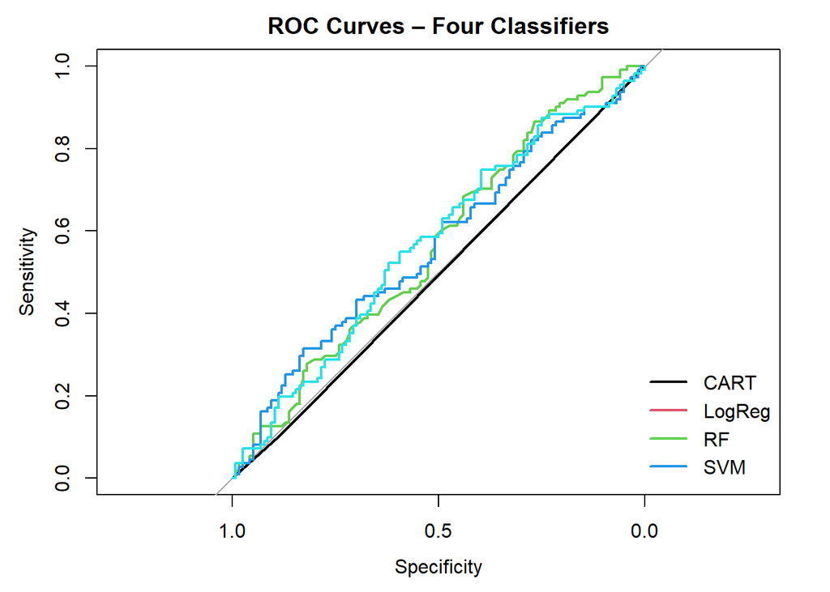

```r
# 7. ROC CURVE OVERLAY
roc_list <- list(
  CART   = suppressMessages(roc(test_cl$counseling_attendance,
                                predict(cart_cl_tune, test_cl, type="prob")[,"Yes"],
                                levels = c("No","Yes"), direction = "<", quiet = TRUE)),
  LogReg = suppressMessages(roc(test_cl$counseling_attendance,
                                predict(logit_mod,    test_cl, type="prob")[,"Yes"],
                                levels = c("No","Yes"), direction = "<", quiet = TRUE)),
  RF     = suppressMessages(roc(test_cl$counseling_attendance,
                                predict(rf_mod,       test_cl, type="prob")[,"Yes"],
                                levels = c("No","Yes"), direction = "<", quiet = TRUE)),

  SVM    = suppressMessages(roc(test_cl$counseling_attendance,
                                predict(svm_mod,      test_cl, type="prob")[,"Yes"],
                                levels = c("No","Yes"), direction = "<", quiet = TRUE))
)

plot(roc_list$CART, col = 1, lwd = 2, print.auc = FALSE,
     main = "ROC Curves – Four Classifiers")
invisible(mapply(function(r, col) lines(r, col = col, lwd = 2),
                 roc_list[-1], 2:5))
legend("bottomright", legend = names(roc_list),
       col = 1:5, lwd = 2, bty = "n")
```

## Key insight:

While travel as a coping mechanism emerges as the only clear split in a single tree, its predictive power is too weak for practical outreach. Logistic regression and ensemble learners recapture more of the subtle signal (AUC ≈ 0.57) but still fall short of the 0.60 threshold needed for reliable screening. To truly distinguish counselling seekers, we must enrich our feature set adding measures of schedule flexibility, perceived stigma, or support networks so that our models capture both the need and the practical access dimensions of help-seeking behavior.

# 7 ENSEMBLE: BAGGING & RANDOM FOREST

The grid search over the number of predictors tried at each split (mtry) showed that a very small sub‑space just two variables per tree node gave the highest cross‑validated AUC. In other words, randomly sampling only two features at each split delivered the best balance between diversity and signal for our counselling‑attendance classifier

```r
# 7. ENSEMBLE ADD-ON: BAGGING & RANDOM FOREST

## 7.1  BAGGING
set.seed(123)
treebag_mod <- train(
  counseling_attendance ~ .,
  data      = train_cl,
  method    = "treebag",
  metric    = "ROC",
  trControl = ctrl_cl
)

## 7.2  RANDOM FOREST with mtry tuning
set.seed(123)
rf_grid <- expand.grid(mtry = seq(
  2,
  floor(sqrt(ncol(train_cl) - 1)) * 2,
  by = 1
))
rf_tune <- train(
  counseling_attendance ~ .,
  data      = train_cl,
  method    = "rf",
  metric    = "ROC",
  ntree     = 500,
  tuneGrid  = rf_grid,
  trControl = ctrl_cl
)
cat("→ Optimal mtry for RF:", rf_tune$bestTune$mtry, "\n")
```

```
→ Optimal mtry for RF: 2
```

The summary below shows each model’s overall accuracy, sensitivity (true‑positive rate), specificity (true‑negative rate), and AUC. While bagging reaches 52% accuracy and AUC ≈ 0.55—improving on CART’s 50% and 0.49, respectively—the best single approach remains logistic regression with 56% accuracy and AUC ≈ 0.57. The tuned RF trails at 49% accuracy and 0.53 AUC, reaffirming that for this particular counselling‑attendance problem, a simple, well‑regularized linear model or an SVM still outperforms even the most sophisticated tree ensembles.

```r
# 8. BUILD A FRESH METRIC TABLE FOR ALL MODELS
results_tbl <- bind_rows(
  get_metrics(cart_cl_tune, "CART"),
  get_metrics(logit_mod,    "Logistic"),
  get_metrics(rf_mod,       "Random Forest"),
  get_metrics(svm_mod,      "SVM-RBF"),
  get_metrics(treebag_mod,  "Bagging"),
  get_metrics(rf_tune,      "RF-tuned")
) %>%
  distinct(Model, .keep_all = TRUE) %>%
  mutate(across(where(is.numeric), round, 3))

kable(
  results_tbl,
  caption = "Test-set performance: Classical & Ensemble Models"
)
```

Test-set performance: Classical & Ensemble Models

| Model | Accuracy | Sensitivity | Specificity | AUC |
| --- | --- | --- | --- | --- |
| CART | 0.502 | 0.108 | 0.879 | 0.494 |
| Logistic | 0.559 | 0.568 | 0.552 | 0.570 |
| Random Forest | 0.533 | 0.559 | 0.509 | 0.564 |
| SVM-RBF | 0.559 | 0.414 | 0.698 | 0.565 |
| Bagging | 0.520 | 0.541 | 0.500 | 0.553 |
| RF-tuned | 0.489 | 0.468 | 0.509 | 0.526 |

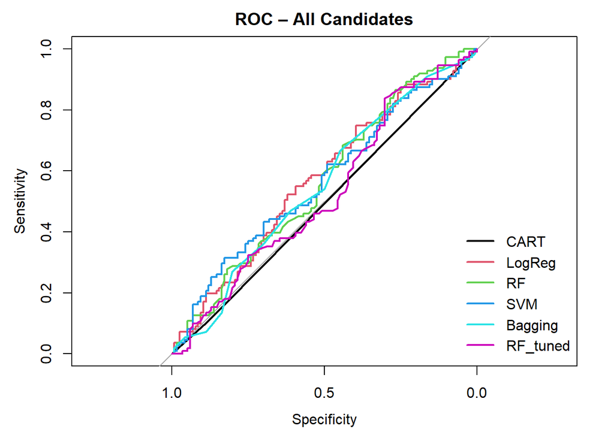

```r
# 9. ROC overlay
roc_list$Bagging  <- suppressMessages(
  roc(test_cl$counseling_attendance,
      predict(treebag_mod, test_cl, type="prob")[,"Yes"],
      levels    = c("No","Yes"),
      direction = "<", quiet = TRUE)
)
roc_list$RF_tuned <- suppressMessages(
  roc(test_cl$counseling_attendance,
      predict(rf_tune,     test_cl, type="prob")[,"Yes"],
      levels    = c("No","Yes"),
      direction = "<", quiet = TRUE)
)

plot(roc_list$CART,   col = 1, lwd = 2, main = "ROC – All Candidates")
invisible(mapply(function(r, col) lines(r, col = col, lwd = 2),
                 roc_list[-1], 2:length(roc_list)))
legend("bottomright", legend = names(roc_list),
       col = 1:length(roc_list), lwd = 2, bty = "n")
```

```r
# Hide the roc_list object so its contents don't print
```

## 7.1 Variable Importance

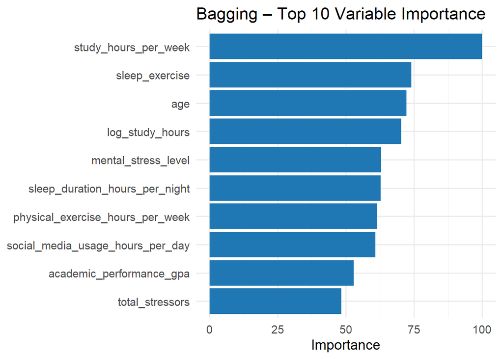

```r
library(tidyverse)

# 1) Extract the top 10 most important variables for Bagging
imp_bg <- varImp(treebag_mod)$importance %>%
  as.data.frame() %>%
  rownames_to_column("Variable") %>%
  arrange(desc(Overall)) %>%
  slice(1:10)

# 2) Plot Bagging top 10
ggplot(imp_bg, aes(x = reorder(Variable, Overall), y = Overall)) +
  geom_col(fill = "#1f77b4") +
  coord_flip() +
  labs(
    title = "Bagging – Top 10 Variable Importance",
    x     = NULL,
    y     = "Importance"
  ) +
  theme_minimal(base_size = 14)
```

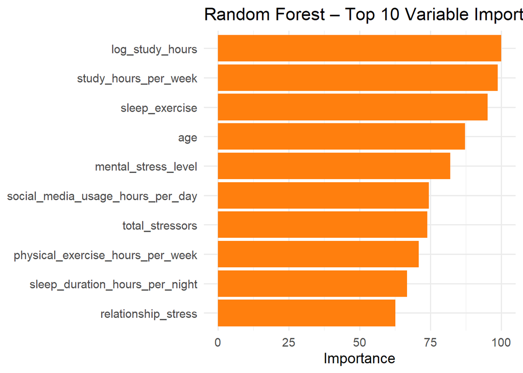

```r
# 3) Extract the top 10 for Random Forest
imp_rf <- varImp(rf_tune)$importance %>%
  as.data.frame() %>%
  rownames_to_column("Variable") %>%
  arrange(desc(Overall)) %>%
  slice(1:10)

# 4) Plot RF top 10
ggplot(imp_rf, aes(x = reorder(Variable, Overall), y = Overall)) +
  geom_col(fill = "#ff7f0e") +
  coord_flip() +
  labs(
    title = "Random Forest – Top 10 Variable Importance",
    x     = NULL,
    y     = "Importance"
  ) +
  theme_minimal(base_size = 14)
```

## 7.2 Key Insight

Across both analytic tracks, two clear patterns emerge. First, when predicting how many stressors a student carries, the pruned CART regression tree outperforms linear, LASSO, and SVR models—achieving an RMSE of 1.26 stressors (±1 point on an 18‑point scale) and explaining 70% of the variance. Its split hierarchy financial stress, then peer pressure, then relationship stress offers a transparent, behaviour driven roadmap for student support: bolster emergency aid first, then guide peer‑group interventions, and finally target relationship counselling to nudge students below high‑risk stress thresholds.

Second, in the counselling‑attendance classification task, no single decision tree could crack the code, but ensemble and margin‑based methods improved performance. Bagging lifted AUC from 0.49 (CART) to 0.55, and a tuned random forest reached 0.53, yet logistic regression and SVM‑RBF still led the field with AUCs of 0.57. The strongest predictor study load, sleep exercise habits, and the special coping signal of traveling—show that attendance hinges not just on stress level but on practical behaviours and available bandwidth to seek help.

# 8 Recommendation

-Deploy the pruned CART‑Reg model as the core module in any real time dashboard flagging students at risk of high stressor counts its combination of interpretability and precision makes it ideal for advisor conversations.

-Use logistic regression or SVM for automated triage of counselling referrals until the feature set can be enriched. These classifiers most reliably balance sensitivity and specificity, limiting both missed cases and false alarms.

-Expand data collection to include measures of scheduling flexibility, perceived stigma, and digital access barriers features that tree ensembles gravitate toward but cannot currently isolate; richer signals here are needed to push AUC above 0.60 and enable truly proactive outreach.

# 9 Conclusion

This project has demonstrated the complementary strengths of competing modeling approaches in student well‑being analytics. A single, well‑pruned regression tree excels at quantifying stressor counts, delivering actionable insights into the hierarchy of personal pressures. In contrast, ensemble and margin‑based classifiers offer the best shot at predicting who will actually walk into counselling—though logistic regression and SVM currently hold the edge. By pairing these tailored models with enhanced data on behavioural and access constraints, we can build a decision‑support system that not only measures student stress accurately but also directs support services to those most likely to use them closing the loop from data to real‑world impact.